# Reto Level 1 - Titanic

Christian Urcuqui

2019-07-17

# 1 Reto de aprendizaje

En el presente notebook se propone un taller que tiene como objetivo poner a prueba los conocimientos acerca de R para la resolución de preguntas de analítica de datos a partir un conjunto de datos que hace parte de un reto propuesto por la plataforma web Kaggle.

**Competencias del estudiante:**

- El lenguaje de programacion R y GitHub.
  - Aplicar los conceptos basicos de codificacion en R.
  - Explorar un data.frame en R.
  - Desarrollar plots básicos en R.
  - Manipular fechas y valores faltantes en R.
  - Aplicar funciones de R para la manipulación de datasets.

# 2 Descripción Titanic

[figure not shown]

En el siguiente enlace puede descargar el dataset de Titanic

```
https://raw.githubusercontent.com/urcuqui/Ciencia-de-datos-ICESI/master/posgrado/datasets/titanic/train_titanic.csv
```

[output not shown]

Se le pide un reporte en HTML donde se permita conocer el proceso y la aplicación de la exploración de datos y la respuesta a las siguientes preguntas:

## 2.1 Complejidad 1

- Explore el dataset e identifique las variables que presentan datos faltantes
- Transforme las variables a los siguientes tipos (solo si es necesario):
  - Name -> Character
  - Ticket -> Character
  - Cabin -> Factor
  - Embarked -> Factor
- Elimine los registros con datos faltantes
- (ggplot) utilice un diagrama que permita conocer cual es el número de registros (valores) más grande para la variable Survived (0,1)
- ¿Quien sobrevivió más, mujeres o hombres?

## 2.2 Complejidad 2

- (ggplot) ¿Existe algo particular entre la edad de las personas y la variable Survived?
- ¿Las familias númerosas sobreviven más?
- ¿Cuál fue el título de las personas que más y menos sobrevivieron en el titanic? **ayuda: con strsplit y un recorrido podras tener el título en el nombre de cada persona**
- Para este conjunto de datos, ¿qué tan cierto es que “Las mujeres y los niños primero…”?

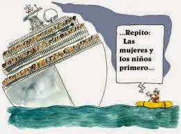

## 2.3 Solución

```r
# 1. cargamos el dataset con el path del archivo csv
dataset <- read.csv(file.choose())
# 2.  damos un vistazo a los datos
summary(dataset)
```

```
##   PassengerId       Survived          Pclass
##  Min.   :  1.0   Min.   :0.0000   Min.   :1.000
##  1st Qu.:223.5   1st Qu.:0.0000   1st Qu.:2.000
##  Median :446.0   Median :0.0000   Median :3.000
##  Mean   :446.0   Mean   :0.3838   Mean   :2.309
##  3rd Qu.:668.5   3rd Qu.:1.0000   3rd Qu.:3.000
##  Max.   :891.0   Max.   :1.0000   Max.   :3.000
##
##                                     Name         Sex           Age
##  Abbing, Mr. Anthony                  :  1   female:314   Min.   : 0.42
##  Abbott, Mr. Rossmore Edward          :  1   male  :577   1st Qu.:20.12
##  Abbott, Mrs. Stanton (Rosa Hunt)     :  1                Median :28.00
##  Abelson, Mr. Samuel                  :  1                Mean   :29.70
##  Abelson, Mrs. Samuel (Hannah Wizosky):  1                3rd Qu.:38.00
##  Adahl, Mr. Mauritz Nils Martin       :  1                Max.   :80.00
##  (Other)                              :885                NA's   :177
##      SibSp           Parch             Ticket         Fare
##  Min.   :0.000   Min.   :0.0000   1601    :  7   Min.   :  0.00
##  1st Qu.:0.000   1st Qu.:0.0000   347082  :  7   1st Qu.:  7.91
##  Median :0.000   Median :0.0000   CA. 2343:  7   Median : 14.45
##  Mean   :0.523   Mean   :0.3816   3101295 :  6   Mean   : 32.20
##  3rd Qu.:1.000   3rd Qu.:0.0000   347088  :  6   3rd Qu.: 31.00
##  Max.   :8.000   Max.   :6.0000   CA 2144 :  6   Max.   :512.33
##                                   (Other) :852
##          Cabin     Embarked
##             :687    :  2
##  B96 B98    :  4   C:168
##  C23 C25 C27:  4   Q: 77
##  G6         :  4   S:644
##  C22 C26    :  3
##  D          :  3
##  (Other)    :186
```

```r
str(dataset)
```

```
## 'data.frame':    891 obs. of  12 variables:
##  $ PassengerId: int  1 2 3 4 5 6 7 8 9 10 ...
##  $ Survived   : int  0 1 1 1 0 0 0 0 1 1 ...
##  $ Pclass     : int  3 1 3 1 3 3 1 3 3 2 ...
##  $ Name       : Factor w/ 891 levels "Abbing, Mr. Anthony",..: 109 191 358 277 16 559 520 629 417 581 ...
##  $ Sex        : Factor w/ 2 levels "female","male": 2 1 1 1 2 2 2 2 1 1 ...
##  $ Age        : num  22 38 26 35 35 NA 54 2 27 14 ...
##  $ SibSp      : int  1 1 0 1 0 0 0 3 0 1 ...
##  $ Parch      : int  0 0 0 0 0 0 0 1 2 0 ...
##  $ Ticket     : Factor w/ 681 levels "110152","110413",..: 524 597 670 50 473 276 86 396 345 133 ...
##  $ Fare       : num  7.25 71.28 7.92 53.1 8.05 ...
##  $ Cabin      : Factor w/ 148 levels "","A10","A14",..: 1 83 1 57 1 1 131 1 1 1 ...
##  $ Embarked   : Factor w/ 4 levels "","C","Q","S": 4 2 4 4 4 3 4 4 4 2 ...
```

```r
# 3.  encontramos unos NA en la variable age, procederemos a eliminar los registros que las contienen
dataset <- na.omit(dataset)
table(is.na(dataset))
```

```
##
## FALSE
##  8568
```

```r
# 4 . Transformación de las variables
dataset$Name <- as.character(dataset$Name)
dataset$Ticket <- as.character(dataset$Ticket)
```

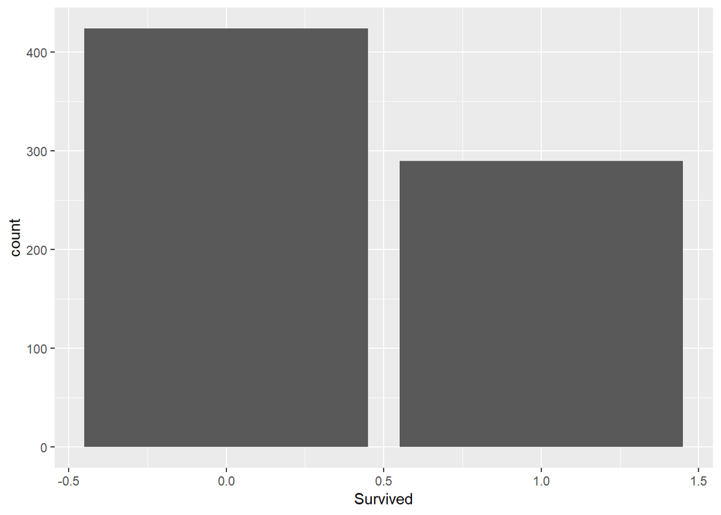

```r
# 4. plot para ver la frecuencia de datos en la variable survived
library(ggplot2)
ggplot(dataset) +
  geom_bar(mapping = aes(Survived))
```

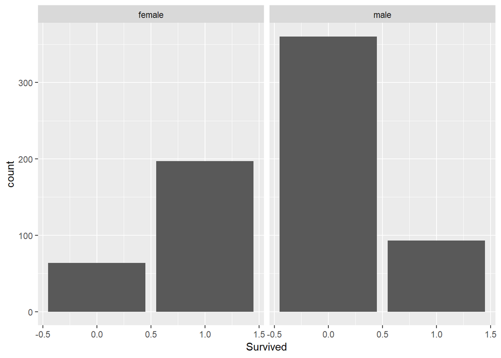

```r
# 5. ¿Quien sobrevivió más, mujeres o hombres?
ggplot(dataset) +
  geom_bar(mapping = aes(Survived)) +
  facet_grid(~Sex)
```

```r
# 5. ¿Cuál fue el título de las personas que más y menos sobrevivió en el titanic?
title <- NULL
for (i in (strsplit(dataset$Name, split=" ")))
{
      title <- c(title,i[2])
}
title <- as.factor(title)
dataset$title <- title
prop.table(table(dataset$Survived, dataset$title))
```

```
##
##       Billiard,       Capt.      Carlo,        Col.   Cruyssen,
##   0 0.001400560 0.001400560 0.001400560 0.001400560 0.001400560
##   1 0.000000000 0.000000000 0.000000000 0.001400560 0.000000000
##
##             der        Don.         Dr.     Gordon,       Impe,
##   0 0.001400560 0.001400560 0.004201681 0.000000000 0.004201681
##   1 0.000000000 0.000000000 0.004201681 0.002801120 0.000000000
##
##       Jonkheer.      Major.     Master. Messemaeker,       Miss.
##   0 0.001400560 0.001400560 0.021008403  0.000000000 0.054621849
##   1 0.000000000 0.001400560 0.029411765  0.001400560 0.145658263
##
##           Mlle.        Mme.         Mr.        Mrs.         Ms.
##   0 0.000000000 0.000000000 0.446778711 0.029411765 0.000000000
##   1 0.002801120 0.001400560 0.092436975 0.116246499 0.001400560
##
##         Mulder, Pelsmaeker,     Planke,        Rev.     Shawah,
##   0 0.000000000 0.001400560 0.004201681 0.008403361 0.001400560
##   1 0.001400560 0.000000000 0.000000000 0.000000000 0.000000000
##
##          Steen,         the      Velde,      Walle,           y
##   0 0.001400560 0.000000000 0.001400560 0.001400560 0.001400560
##   1 0.000000000 0.001400560 0.000000000 0.000000000 0.002801120
```